# InClassEx5 Owen 5714

## IC#5

1. Perform a t-test for assessing significant differences in mean fev by sex. What is the p-value for the t-test? Is there a significant difference in mean fev by sex? Provide evidence to support your conclusion.

```r
fev <- read.csv("~/Desktop/BIOST_509_2017/fev2.csv")
fev$sexfactor=as.factor(fev$sex)
t.test(fev~sexfactor,data=fev)
```

```
##
##  Welch Two Sample t-test
##
## data:  fev by sexfactor
## t = 5.5037, df = 575.75, p-value = 5.604e-08
## alternative hypothesis: true difference in means is not equal to 0
## 95 percent confidence interval:
##  0.2323494 0.4902038
## sample estimates:
## mean in group 1 mean in group 2
##        2.812446        2.451170
```

The difference in mean FEV for the sexes is statistically significantly different at p<5.6e-8.

2. Now perform a linear regression analysis with fev as the response (dependent) variable and sex as the predictor (independent) variable. Provide an interpretation of the coefficient for sex. Provide a 95% confidence interval for the coefficient of sex. Is there significant evidence that fev differs by sex? What is the value of R-squared for the model you fit. From the regression model, calculate the mean fev for females and the mean fev for males. Compare your association results from the linear regression model to the t-test results you obtained in question 1.

```r
lm1 <- lm(fev~sexfactor,data=fev)
summary(lm1)
```

```
##
## Call:
## lm(formula = fev ~ sexfactor, data = fev)
##
## Residuals:
##      Min       1Q   Median       3Q      Max
## -2.01645 -0.69420 -0.06367  0.58233  2.98055
##
## Coefficients:
##             Estimate Std. Error t value Pr(>|t|)
## (Intercept)   2.8125     0.0463  60.746  < 2e-16 ***
## sexfactor2   -0.3613     0.0664  -5.441  7.5e-08 ***
## ---
## Signif. codes:  0 '***' 0.001 '**' 0.01 '*' 0.05 '.' 0.1 ' ' 1
##
## Residual standard error: 0.8487 on 652 degrees of freedom
## Multiple R-squared:  0.04344,    Adjusted R-squared:  0.04197
## F-statistic: 29.61 on 1 and 652 DF,  p-value: 7.496e-08
```

```r
confint(lm1,parm="sexfactor2",level=0.95)
```

```
##                2.5 %     97.5 %
## sexfactor2 -0.491653 -0.2309002
```

3. Now perform a linear regression analysis with fev as the response and height as the predictor. Describe the relationship between the two variables based on the output from your regression analysis. Is there significant evidence of an association between fev and height? Provide evidence to support your conclusion.

```r
lm1 <- lm(fev~height,data=fev)
summary(lm1)
```

```
##
## Call:
## lm(formula = fev ~ height, data = fev)
##
## Residuals:
##      Min       1Q   Median       3Q      Max
## -1.75167 -0.26619 -0.00401  0.24474  2.11936
##
## Coefficients:
##              Estimate Std. Error t value Pr(>|t|)
## (Intercept) -5.432679   0.181460  -29.94   <2e-16 ***
## height       0.131976   0.002955   44.66   <2e-16 ***
## ---
## Signif. codes:  0 '***' 0.001 '**' 0.01 '*' 0.05 '.' 0.1 ' ' 1
##
## Residual standard error: 0.4307 on 652 degrees of freedom
## Multiple R-squared:  0.7537, Adjusted R-squared:  0.7533
## F-statistic:  1995 on 1 and 652 DF,  p-value: < 2.2e-16
```

There is a statistically significant association between height and fev (p<2e-16), for every single unit (inch) of height increase, FEV increases by 0.132.

4. Provide a scatterplot of fev versus height and include in the plot the regression line for predicting fev from height.

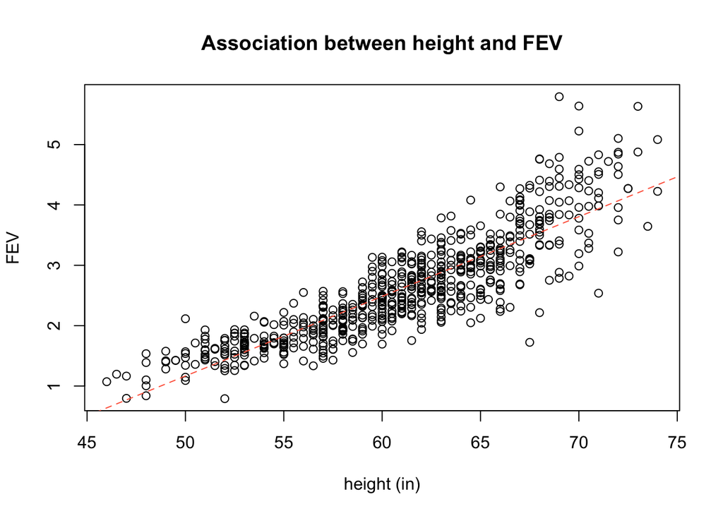

```r
plot(fev$height,fev$fev,xlab="height (in)",ylab="FEV",main="Association between height and FEV")
abline(lm1,col="tomato",lty=2)
```

5. Make a pairs plot of the variables fev, height, age and sex. Conduct a multiple linear regression analysis with fev as the response and with height, age and sex included as predictors. Print out the summary table of the results. Which predictors are significant in the model? Provide the p-values for all three predictors.

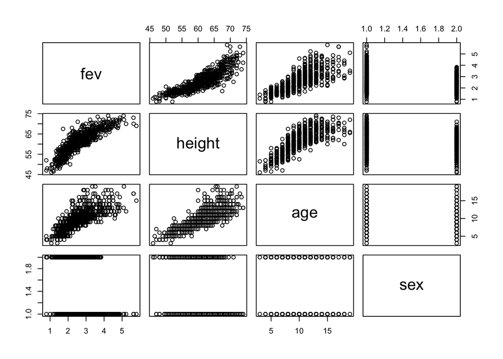

```r
pairs(fev[,c("fev","height","age","sex")])
```

```r
lm2=lm(fev~height+age+sexfactor,data=fev)
summary(lm2)
```

```
##
## Call:
## lm(formula = fev ~ height + age + sexfactor, data = fev)
##
## Residuals:
##      Min       1Q   Median       3Q      Max
## -1.37613 -0.24834  0.01051  0.25748  1.94538
##
## Coefficients:
##              Estimate Std. Error t value Pr(>|t|)
## (Intercept) -4.287448   0.230253 -18.621  < 2e-16 ***
## height       0.104560   0.004756  21.986  < 2e-16 ***
## age          0.061364   0.009069   6.766 2.96e-11 ***
## sexfactor2  -0.161112   0.033125  -4.864 1.45e-06 ***
## ---
## Signif. codes:  0 '***' 0.001 '**' 0.01 '*' 0.05 '.' 0.1 ' ' 1
##
## Residual standard error: 0.4126 on 650 degrees of freedom
## Multiple R-squared:  0.7746, Adjusted R-squared:  0.7736
## F-statistic: 744.6 on 3 and 650 DF,  p-value: < 2.2e-16
```

All three variables are significantly associated with FEV, height is significant at p<2e-16, then factoring in age is significant at p<2.96e-11, and sex is significant at p<1.45e-6.